# vMemEcc Behavior Analysis

Felix Klotzsche — eioe

July 11, 2019

Imports & loadings:

```r
library(tidyverse)
library(here)


source(here("Utils", "wrangle_data.R"))
source(here("Utils", "plot_behavior.R"))
```

# Data loading

*overview*:  
**P001 & P002**:  
- very early pilots that did lots of beta testing  
- only vMem Task, no perception task  
P001: 432 trials  
P002: 288 trials

**P01, P02, P03, P04**:  
- more serious pilots (I also have EEG data of them)  
- their trials include 20 training trials and  
- 144 (P01) and 96 (P02, P03, P04) trials from the “perception”/Change detection task  
P01: 607 trials  
P02: 260 trials (no cortical magnification)  
P03: 548 trials (no cortical magnification, cM)  
P04: 960 trials (no cM), was not fixating in the first 4 blocks  
(so basically only the last 3 blocks of the experimental condition are reliable), s/he was also ocassionally mixing up the response buttons P05: 960 trials

Finally, I put them all into one big data frame:

```r
# build a global data frame:
fulldat <- bind_rows(datP01,
                     datP02,
                     datP03,
                     datP04,
                     datP05,
                     datP06,
                     datP07,
                     datP08,
                     datP09,
                     datP001,
                     datP002)

# and restructure it:
fulldat <- fulldat %>%
             mutate_at(vars(ppid,
                            c_Ecc,
                            c_CortMag,
                            c_StimN
                       ),
                       factor) %>%

             mutate_at(vars(c_ResponseCorrect),
                       as.logical) %>%

             drop_na(c_Response) %>%

             mutate(c_ResponseCorrect = (c_Response == c_Change))
```

*Noteworthy*: I filter out all trials in which the cortical magnification scaling was applied.

```r
fulldat_nocM <- filter(fulldat, c_CortMag == 0)
```

## Plots

Now we can take a look a the outcomes:

**Visual Memory Task Performance:**

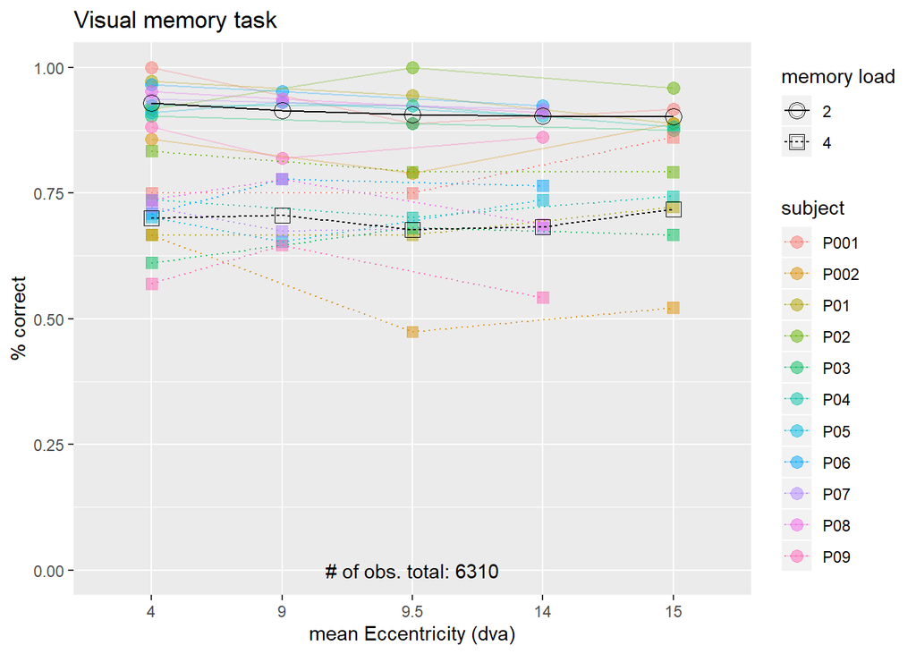

```r
plot_performance(fulldat_nocM, "experiment")
```

The average is plotted in black.  
Apparently, there does not seem a very big effect of *Eccentrcity* on the performance for these subjects. (these are all cases without cM scaling!)  
But clearly the task is more difficult for 4 than for 2 items.

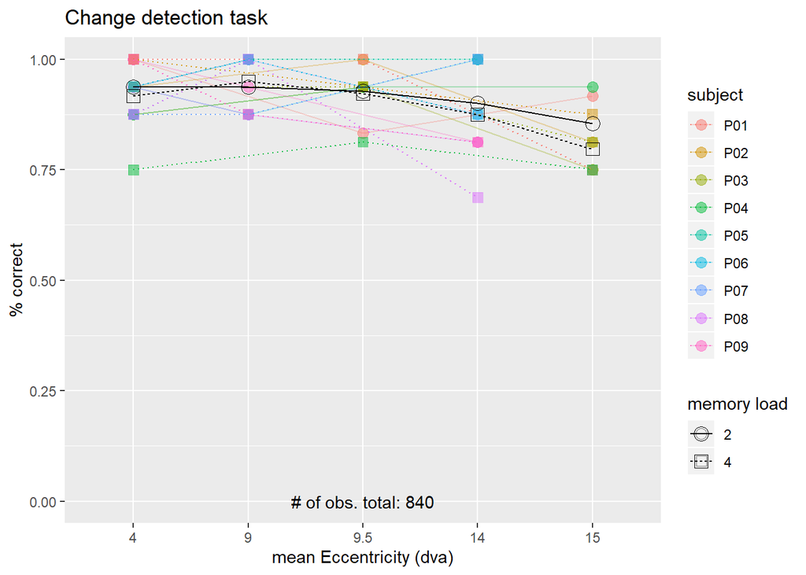

```r
plot_performance(fulldat_nocM, "perception")
```

This is wat we expected: people are really good in this. There is not even a real difference between set size conditions. Surprisingly, here it looks more like there could be an effect of *Eccentricity*, but it’s a very small number of trials.

Now the same for the trials where cort. Magn. scaling was applied:

```r
fulldat_cM <- filter(fulldat, c_CortMag == 2)
```

**Visual Memory Task Performance:**

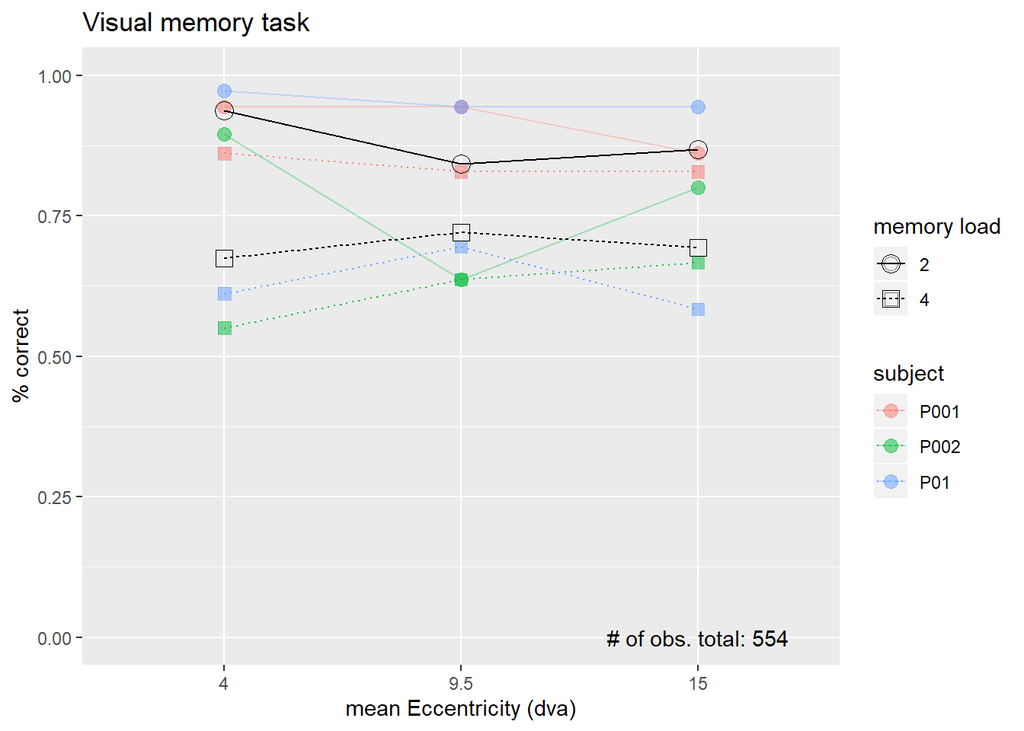

```r
plot_performance(fulldat_cM, "experiment")
```

**Change Perception Task**  
(Only 1 subject underwent this condition)

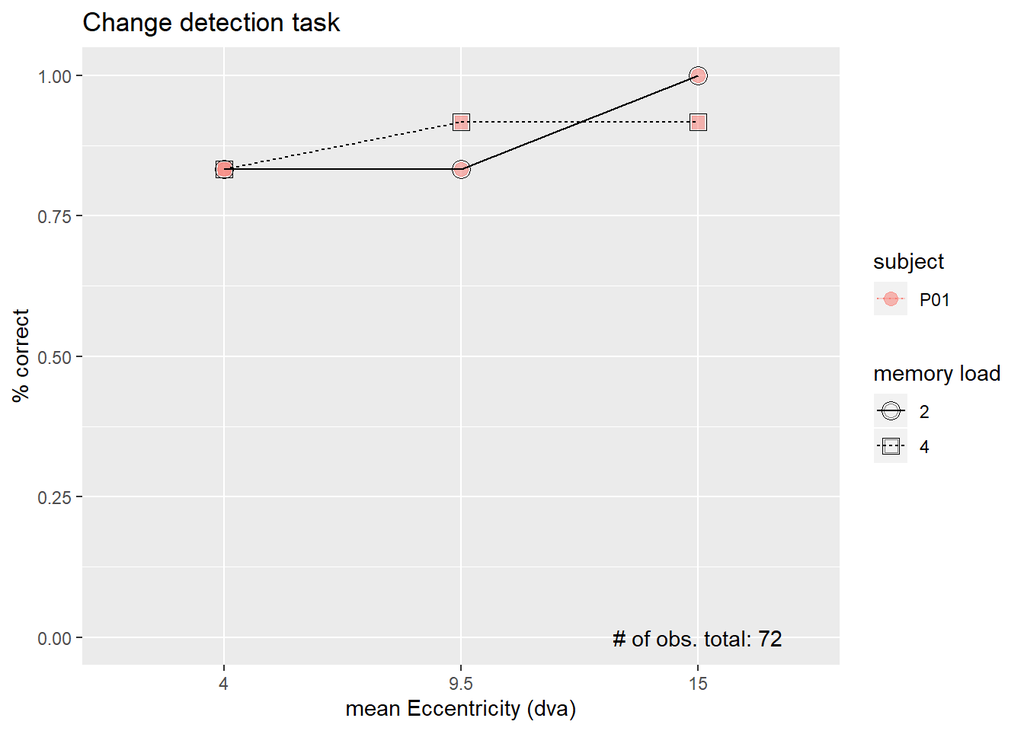

```r
plot_performance(fulldat_cM, "perception")
```

**Sanity checks**

```r
datP08 %>% filter(BlockStyle == "experiment") %>%
  group_by(c_Ecc, c_CueDir, c_Change, c_StimN) %>%
  summarise(nT = n())
```

```
## # A tibble: 24 x 5
## # Groups:   c_Ecc, c_CueDir, c_Change [12]
##    c_Ecc c_CueDir c_Change c_StimN    nT
##    <dbl>    <dbl> <lgl>      <dbl> <int>
##  1     4       -1 FALSE          2    36
##  2     4       -1 FALSE          4    36
##  3     4       -1 TRUE           2    36
##  4     4       -1 TRUE           4    36
##  5     4        1 FALSE          2    36
##  6     4        1 FALSE          4    36
##  7     4        1 TRUE           2    36
##  8     4        1 TRUE           4    36
##  9     9       -1 FALSE          2    36
## 10     9       -1 FALSE          4    36
## # ... with 14 more rows
```

```r
datP09 %>% filter(BlockStyle == "experiment") %>%
  group_by(c_Response, c_StimN) %>%
  summarise(RespBias = n())
```

```
## # A tibble: 4 x 3
## # Groups:   c_Response [2]
##   c_Response c_StimN RespBias
##   <lgl>        <dbl>    <int>
## 1 FALSE            2      215
## 2 FALSE            4      331
## 3 TRUE             2      217
## 4 TRUE             4      101
```